# OSM, Cycling, R

Tim Foster @fozy81

March 16, 2016

## The potted history of a shiny app

- Cycling
- OpenStreetMap (OSM)
- R / shiny

## Rating the cycle infrastructure in your area

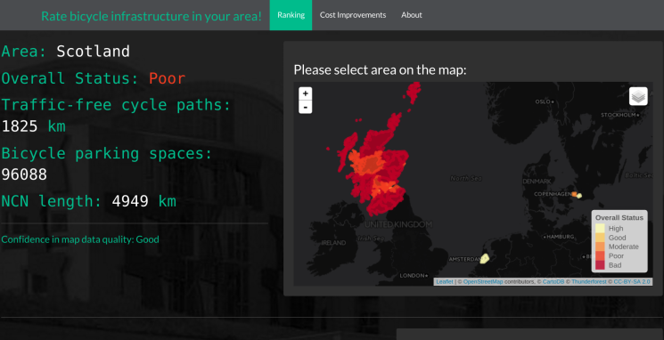

## Cycling

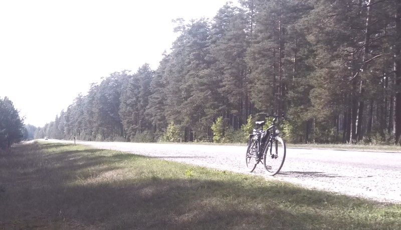

## Cycling

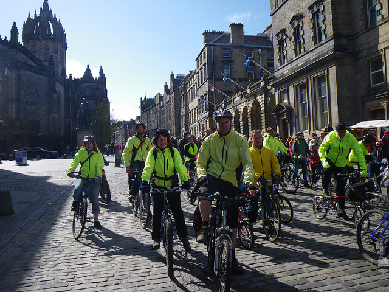

## Traffic

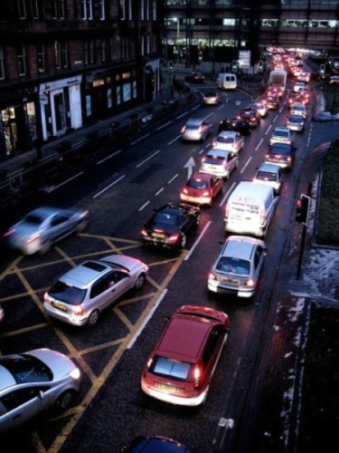

## Cycling

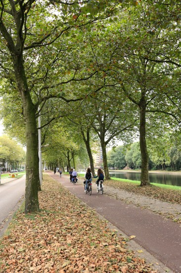

## Cycling

- Cyclehack - Glasgow 2014 & 2015
- Can we use data to rate and improve cycle paths?

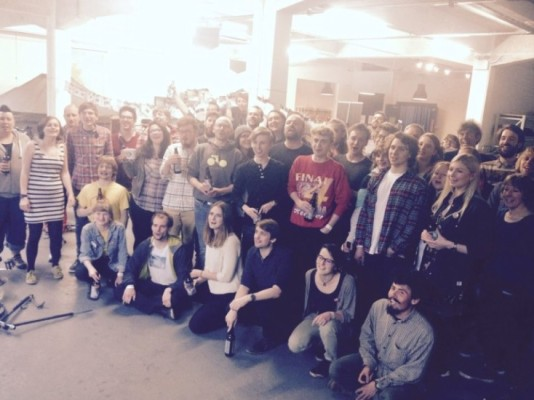

## Where's the data?

- OS
- Google
- Strava
- Others? (aerial imagery - ML?)

## OpenStreetMap

- Free, Open Data, Worldwide
- Terrabyte of data
- Constantly updated + lots of cycling information
- It's amazing!

## OpenStreetMap + cycle

[figure not shown]

## OpenStreetMap edit video

https://www.youtube.com/watch?v=7sC83j6vzjo

## OpenStreetMap

[interactive chart not shown]

[View Larger Map](http://www.openstreetmap.org/#map=15/56.0028/-2.5216)

## OpenStreetMap

- Data is patchy
- Inconsistent tagging/structure
- Quantitive not qualitive

## Using OpenStreeMap

- osmar package in R - that's great to get started
- overpass turbo API - no package yet!
- Large downloads need to use postgres + postgis database - bit of a fiddle

## Workflow

- Data downloaded (Geofabrik & Metro Extracts)
- Import in postgres database
- Use ROBDC in R to query postgres for summary stats

OSM > POSTGRES > R

## Stats

Inspired by: * SIMD - Indexes/Ranking

[figure not shown]

- Water Framework Directive- Observed/Expected

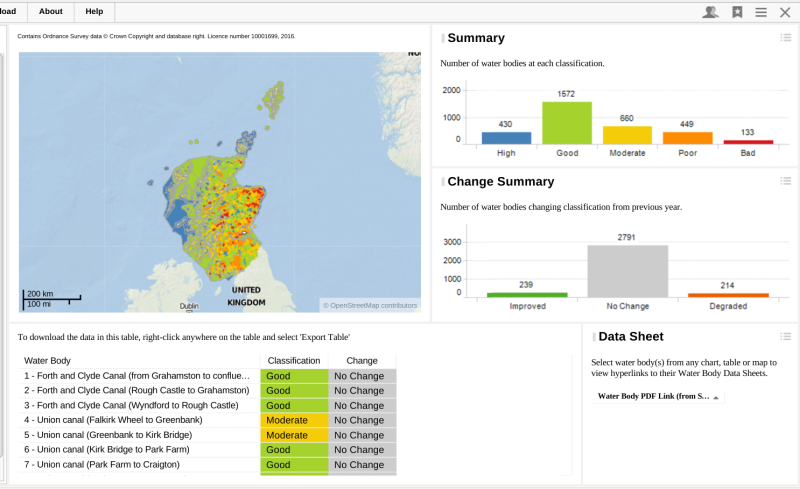

## Stats

- Takes Amsterdam as the best example of cycling infrastructure / highest number of people cycling
- Compares all other areas to Amsterdam (after standardising) for:
- - Cycle parking
- - Cycle paths
- - National cycle routes

## Stats

- Uses Amsterdam as expected/ideal level of cycle infrastructure
- Compares any given area to Amsterdam
- Standardising uses area size and total length of road

## Code bit

- stats are in the github package 'bikr'
- www.github.com/fozy81/bikr

## Visualising

- 1 Static web page - maps created in R
- 2 Started with python (flask web server) + javascript
- 3 Shiny framework - back to using R

## Demo

## Future

- need help with postGIS
- R improvements
- download the package - pull requests!

## Thank you

Remember: Cycling makes you a better R coder!

@fozy81

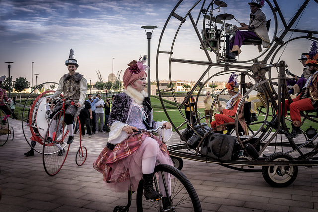